# Capstone Project NLP-2

**• DOMAIN:** Industrial safety. NLP based Chatbot.

**• CONTEXT:** The database comes from one of the biggest industry in Brazil and in the world. It is an urgent need for industries/companies around the globe to understand why employees still suffer some injuries/accidents in plants. Sometimes they also die in such environment.

**• DATA DESCRIPTION:** This The database is basically records of accidents from 12 different plants in 03 different countries which every line in the data is an occurrence of an accident. Columns description:

‣ Data: timestamp or time/date information

‣ Countries: which country the accident occurred (anonymised)

‣ Local: the city where the manufacturing plant is located (anonymised)

‣ Industry sector: which sector the plant belongs to

‣ Accident level: from I to VI, it registers how severe was the accident (I means not severe but VI means very severe)

‣ Potential Accident Level: Depending on the Accident Level, the database also registers how severe the accident could have been (due to other factors involved in the accident)

‣ Genre: if the person is male of female

‣ Employee or Third Party: if the injured person is an employee or a third party

‣ Critical Risk: some description of the risk involved in the accident

‣ Description: Detailed description of how the accident happened.

**• PROJECT OBJECTIVE:** Design a ML/DL based chatbot utility which can help the professionals to highlight the safety risk as per the incident description.

## Milestone 1

**PROJECT TASK:**

‣ Step 1: Import the data

‣ Step 2: Data cleansing

‣ Step 3: Data preprocessing

‣ Step 4: Data preparation to be used for AIML model learning

```python
!pip install unidecode
!pip install autocorrect
!pip install google_trans_new
!pip install ann_visualizer
!pip install googletrans
```

```python
!pip install nltk
```

```python
#!pip install wordcloud
```

```python
# Importing all the necessary libraries
import warnings # to ignore warnings
warnings.filterwarnings('ignore')

import numpy as np
import pandas as pd
import seaborn as sns
from matplotlib import pyplot as plt
%matplotlib inline

from sklearn.preprocessing import LabelEncoder

from sklearn.model_selection import train_test_split, cross_val_score

from sklearn.linear_model import LogisticRegression
from sklearn.naive_bayes import GaussianNB
from sklearn.neighbors import KNeighborsClassifier
from sklearn.svm import SVC
from sklearn.tree import DecisionTreeClassifier
from sklearn.ensemble import RandomForestClassifier, BaggingClassifier, AdaBoostClassifier, GradientBoostingClassifier
#from xgboost import XGBClassifier

from sklearn.metrics import classification_report, confusion_matrix

import nltk
from nltk.corpus import stopwords
from nltk import tokenize, stem
from tensorflow.keras.preprocessing.text import Tokenizer

import re
import string
from nltk.probability import FreqDist
from nltk.util import ngrams
from nltk.tokenize import word_tokenize
from nltk.stem import WordNetLemmatizer

import unicodedata
import unidecode
from autocorrect import Speller
from string import punctuation
#from wordcloud import WordCloud, STOPWORDS
#from textblob import TextBlob

from sklearn.feature_extraction.text import CountVectorizer
from sklearn.feature_extraction.text import TfidfVectorizer
#from gensim.models import Word2Vec

from tensorflow.keras.preprocessing.sequence import pad_sequences
from tensorflow.keras.layers import Dense, Input, LSTM, Embedding, Dropout, Activation, Flatten, Bidirectional, GlobalMaxPool1D
from tensorflow.keras.models import Model, Sequential
from tensorflow.keras.utils import to_categorical

from keras.callbacks import EarlyStopping, ModelCheckpoint

from google_trans_new import google_translator

from ann_visualizer.visualize import ann_viz;
from keras.utils.vis_utils import plot_model
```

```python
#from google.colab import drive
#drive.mount('/content/drive')
```

```python
#import the Dataset
#path = '/content/drive/MyDrive/Great Learning Projects/Capstone Project/IHMStefanini_industrial_safety_and_health_database_with_accidents_description.csv'
path = r"C:\Users\ADMIN\Great Learning Study Material\Capstone Project\IHMStefanini_industrial_safety_and_health_database_with_accidents_description.csv"
df = pd.read_csv(path)
```

### Exploratory Data Analysis

```python
df.head()
```

|  | Unnamed: 0 | Data | Countries | Local | Industry Sector | Accident Level | Potential Accident Level | Genre | Employee or Third Party | Critical Risk | Description |
| --- | --- | --- | --- | --- | --- | --- | --- | --- | --- | --- | --- |
| 0 | 0 | 2016-01-01 00:00:00 | Country_01 | Local_01 | Mining | I | IV | Male | Third Party | Pressed | While removing the drill rod of the Jumbo 08 f... |
| 1 | 1 | 2016-01-02 00:00:00 | Country_02 | Local_02 | Mining | I | IV | Male | Employee | Pressurized Systems | During the activation of a sodium sulphide pum... |
| 2 | 2 | 2016-01-06 00:00:00 | Country_01 | Local_03 | Mining | I | III | Male | Third Party (Remote) | Manual Tools | In the sub-station MILPO located at level +170... |
| 3 | 3 | 2016-01-08 00:00:00 | Country_01 | Local_04 | Mining | I | I | Male | Third Party | Others | Being 9:45 am. approximately in the Nv. 1880 C... |
| 4 | 4 | 2016-01-10 00:00:00 | Country_01 | Local_04 | Mining | IV | IV | Male | Third Party | Others | Approximately at 11:45 a.m. in circumstances t... |

```python
df.describe(include ='all')
```

|  | Unnamed: 0 | Data | Countries | Local | Industry Sector | Accident Level | Potential Accident Level | Genre | Employee or Third Party | Critical Risk | Description |
| --- | --- | --- | --- | --- | --- | --- | --- | --- | --- | --- | --- |
| count | 425.000000 | 425 | 425 | 425 | 425 | 425 | 425 | 425 | 425 | 425 | 425 |
| unique | NaN | 287 | 3 | 12 | 3 | 5 | 6 | 2 | 3 | 33 | 411 |
| top | NaN | 2017-02-08 00:00:00 | Country_01 | Local_03 | Mining | I | IV | Male | Third Party | Others | During the activity of chuteo of ore in hopper... |
| freq | NaN | 6 | 251 | 90 | 241 | 316 | 143 | 403 | 189 | 232 | 3 |
| mean | 224.084706 | NaN | NaN | NaN | NaN | NaN | NaN | NaN | NaN | NaN | NaN |
| std | 125.526786 | NaN | NaN | NaN | NaN | NaN | NaN | NaN | NaN | NaN | NaN |
| min | 0.000000 | NaN | NaN | NaN | NaN | NaN | NaN | NaN | NaN | NaN | NaN |
| 25% | 118.000000 | NaN | NaN | NaN | NaN | NaN | NaN | NaN | NaN | NaN | NaN |
| 50% | 226.000000 | NaN | NaN | NaN | NaN | NaN | NaN | NaN | NaN | NaN | NaN |
| 75% | 332.000000 | NaN | NaN | NaN | NaN | NaN | NaN | NaN | NaN | NaN | NaN |
| max | 438.000000 | NaN | NaN | NaN | NaN | NaN | NaN | NaN | NaN | NaN | NaN |

We can see that :

1. There are no Nulls.
2. There seem to be duplicates in the data.
3. Column 0 is of no use we'll drop the column for further analysis.

We'll check again in the detailed summary

```python
# Drop irrelevant column Unnamed:0
df.drop('Unnamed: 0', axis=1, inplace=True)
```

```python
# Rename the columns in a correct fashion
df.rename(columns = { 'Data' : 'Date',
                      'Industry Sector' : 'Industry_Sector',
                      'Accident Level': 'Accident_Level',
                      'Countries' : 'Country',
                      'Genre' : 'Gender',
                      'Potential Accident Level' : 'Potential_Accident_Level',
                      'Employee or Third Party' : 'Employee_Type',
                      'Critical Risk' : 'Critical_Risk'}, inplace = True)
```

```python
# Defining a function which gives the dataframe with all the analysis.
def indetailtable(df):
    print('Dataset Shape: {}'.format(df.shape))
    print('Total Number of rows in dataset: {}'.format(df.shape[0]))
    print('Total Number of columns in dataset: {}'.format(df.shape[1]))
    print('Various datatypes present in the dataset are: {}'.format(df.dtypes.value_counts()))

    summary = pd.DataFrame(df.dtypes, columns = ['dtypes'])
    summary = summary.reset_index()
    summary['Name'] = summary['index']
    summary['Name'] = summary['Name']
    summary['Misssing_values'] = df.isnull().sum().values
    summary['Unique_values'] = df.nunique().values
    summary['Duplicate_values'] = df.duplicated().sum()
    summary['1st value'] = df.loc[0].values
    summary['2nd Value'] = df.loc[1].values
    summary['423th Value'] = df.iloc[-2].values
    summary['424th Value'] = df.iloc[-1].values

    return summary
```

```python
# Calling the above defined function by giving the input as a dataframe
indetailtable(df)
```

```
Dataset Shape: (425, 10)
Total Number of rows in dataset: 425
Total Number of columns in dataset: 10
Various datatypes present in the dataset are: object    10
dtype: int64
```

|  | index | dtypes | Name | Misssing_values | Unique_values | Duplicate_values | 1st value | 2nd Value | 423th Value | 424th Value |
| --- | --- | --- | --- | --- | --- | --- | --- | --- | --- | --- |
| 0 | Date | object | Date | 0 | 287 | 7 | 2016-01-01 00:00:00 | 2016-01-02 00:00:00 | 2017-07-06 00:00:00 | 2017-07-09 00:00:00 |
| 1 | Country | object | Country | 0 | 3 | 7 | Country_01 | Country_02 | Country_02 | Country_01 |
| 2 | Local | object | Local | 0 | 12 | 7 | Local_01 | Local_02 | Local_05 | Local_04 |
| 3 | Industry_Sector | object | Industry_Sector | 0 | 3 | 7 | Mining | Mining | Metals | Mining |
| 4 | Accident_Level | object | Accident_Level | 0 | 5 | 7 | I | I | I | I |
| 5 | Potential_Accident_Level | object | Potential_Accident_Level | 0 | 6 | 7 | IV | IV | II | II |
| 6 | Gender | object | Gender | 0 | 2 | 7 | Male | Male | Male | Female |
| 7 | Employee_Type | object | Employee_Type | 0 | 3 | 7 | Third Party | Employee | Employee | Third Party |
| 8 | Critical_Risk | object | Critical_Risk | 0 | 33 | 7 | Pressed | Pressurized Systems | Cut | Fall prevention (same level) |
| 9 | Description | object | Description | 0 | 411 | 7 | While removing the drill rod of the Jumbo 08 f... | During the activation of a sodium sulphide pum... | The Employee performed the activity of strippi... | At 10:00 a.m., when the assistant cleaned the ... |

Insights:

Dataset contains total of 10 columns in which all are object data type. There are no null / missing values present in the dataset, hence we can safely move ahead.

There are 7 duplicates for which all the columns have same value, These duplicate records refer to different persons involved in the same accident.

There are only 7 records hence we will be dropping them down the line. As capturing the number of people will not be helpful in our analysis.

```python
# Checking those the duplicates we found in above dataframe
print('There are {} duplicates in the dataset as below'.format(df.duplicated().sum()))
df[df.duplicated()]
```

```
There are 7 duplicates in the dataset as below
```

|  | Date | Country | Local | Industry_Sector | Accident_Level | Potential_Accident_Level | Gender | Employee_Type | Critical_Risk | Description |
| --- | --- | --- | --- | --- | --- | --- | --- | --- | --- | --- |
| 77 | 2016-04-01 00:00:00 | Country_01 | Local_01 | Mining | I | V | Male | Third Party (Remote) | Others | In circumstances that two workers of the Abrat... |
| 262 | 2016-12-01 00:00:00 | Country_01 | Local_03 | Mining | I | IV | Male | Employee | Others | During the activity of chuteo of ore in hopper... |
| 303 | 2017-01-21 00:00:00 | Country_02 | Local_02 | Mining | I | I | Male | Third Party (Remote) | Others | Employees engaged in the removal of material f... |
| 345 | 2017-03-02 00:00:00 | Country_03 | Local_10 | Others | I | I | Male | Third Party | Venomous Animals | On 02/03/17 during the soil sampling in the re... |
| 346 | 2017-03-02 00:00:00 | Country_03 | Local_10 | Others | I | I | Male | Third Party | Venomous Animals | On 02/03/17 during the soil sampling in the re... |
| 355 | 2017-03-15 00:00:00 | Country_03 | Local_10 | Others | I | I | Male | Third Party | Venomous Animals | Team of the VMS Project performed soil collect... |
| 397 | 2017-05-23 00:00:00 | Country_01 | Local_04 | Mining | I | IV | Male | Third Party | Projection of fragments | In moments when the 02 collaborators carried o... |

```python
# Drop the duplicate values from the dataframe using drop_duplicates function.
df.drop_duplicates(inplace=True)
print('After removing duplicates the shape of the dataset is:',df.shape)
```

```
After removing duplicates the shape of the dataset is: (418, 10)
```

```python
# Calling the function again to get some more insights
indetailtable(df)
```

```
Dataset Shape: (418, 10)
Total Number of rows in dataset: 418
Total Number of columns in dataset: 10
Various datatypes present in the dataset are: object    10
dtype: int64
```

|  | index | dtypes | Name | Misssing_values | Unique_values | Duplicate_values | 1st value | 2nd Value | 423th Value | 424th Value |
| --- | --- | --- | --- | --- | --- | --- | --- | --- | --- | --- |
| 0 | Date | object | Date | 0 | 287 | 0 | 2016-01-01 00:00:00 | 2016-01-02 00:00:00 | 2017-07-06 00:00:00 | 2017-07-09 00:00:00 |
| 1 | Country | object | Country | 0 | 3 | 0 | Country_01 | Country_02 | Country_02 | Country_01 |
| 2 | Local | object | Local | 0 | 12 | 0 | Local_01 | Local_02 | Local_05 | Local_04 |
| 3 | Industry_Sector | object | Industry_Sector | 0 | 3 | 0 | Mining | Mining | Metals | Mining |
| 4 | Accident_Level | object | Accident_Level | 0 | 5 | 0 | I | I | I | I |
| 5 | Potential_Accident_Level | object | Potential_Accident_Level | 0 | 6 | 0 | IV | IV | II | II |
| 6 | Gender | object | Gender | 0 | 2 | 0 | Male | Male | Male | Female |
| 7 | Employee_Type | object | Employee_Type | 0 | 3 | 0 | Third Party | Employee | Employee | Third Party |
| 8 | Critical_Risk | object | Critical_Risk | 0 | 33 | 0 | Pressed | Pressurized Systems | Cut | Fall prevention (same level) |
| 9 | Description | object | Description | 0 | 411 | 0 | While removing the drill rod of the Jumbo 08 f... | During the activation of a sodium sulphide pum... | The Employee performed the activity of strippi... | At 10:00 a.m., when the assistant cleaned the ... |

- One can observe in the above dataframe that there are only 411 unique values in the Description column but we have 418 number of records in total, we can assume that there are still 7 number of duplicate values on description column.
- We will check for those duplicates on column level and drop if required for further analysis.

```python
# Printing all the duplicate values (keep=False)
print('There are still {} duplicates in the dataset as below'.format(df.duplicated(subset=['Description'],keep=False).sum()))
df[df.duplicated(subset=['Description'],keep=False)].sort_values(by='Description')
```

```
There are still 14 duplicates in the dataset as below
```

|  | Date | Country | Local | Industry_Sector | Accident_Level | Potential_Accident_Level | Gender | Employee_Type | Critical_Risk | Description |
| --- | --- | --- | --- | --- | --- | --- | --- | --- | --- | --- |
| 166 | 2016-07-07 00:00:00 | Country_01 | Local_03 | Mining | IV | V | Male | Third Party | Others | At moments when the MAPERU truck of plate F1T ... |
| 167 | 2016-07-07 00:00:00 | Country_01 | Local_03 | Mining | I | IV | Male | Third Party | Others | At moments when the MAPERU truck of plate F1T ... |
| 261 | 2016-12-01 00:00:00 | Country_01 | Local_03 | Mining | I | IV | Male | Employee | Others | During the activity of chuteo of ore in hopper... |
| 263 | 2016-12-01 00:00:00 | Country_01 | Local_03 | Mining | I | IV | Male | Third Party | Others | During the activity of chuteo of ore in hopper... |
| 412 | 2017-06-20 00:00:00 | Country_01 | Local_01 | Mining | I | IV | Male | Employee | Others | In circumstance, the AHK-903 license plate (Em... |
| 413 | 2017-06-20 00:00:00 | Country_01 | Local_01 | Mining | I | IV | Male | Third Party | Others | In circumstance, the AHK-903 license plate (Em... |
| 130 | 2016-05-26 00:00:00 | Country_03 | Local_10 | Others | I | I | Male | Third Party | Bees | In the geological reconnaissance activity, in ... |
| 131 | 2016-05-26 00:00:00 | Country_03 | Local_10 | Others | I | I | Male | Employee | Others | In the geological reconnaissance activity, in ... |
| 143 | 2016-06-08 00:00:00 | Country_03 | Local_10 | Others | I | I | Male | Third Party | Bees | Project of Vazante that carried out sediment c... |
| 144 | 2016-06-08 00:00:00 | Country_03 | Local_10 | Others | I | I | Male | Third Party | Others | Project of Vazante that carried out sediment c... |
| 387 | 2017-05-06 00:00:00 | Country_02 | Local_07 | Mining | IV | V | Male | Employee | Projection | The employees Márcio and Sérgio performed the ... |
| 388 | 2017-05-06 00:00:00 | Country_02 | Local_07 | Mining | II | V | Male | Employee | Projection | The employees Márcio and Sérgio performed the ... |
| 37 | 2016-02-24 00:00:00 | Country_02 | Local_07 | Mining | I | V | Male | Employee | Others | When starting the activity of removing a coil ... |
| 38 | 2016-02-24 00:00:00 | Country_02 | Local_07 | Mining | I | V | Female | Third Party | Others | When starting the activity of removing a coil ... |

- We can cleary observe that the above dataframe contains 7 duplicates in which only one or two column values are dissimilar among the datapoints where in the Description is matching, which is logically unsound.
- It can also be noticed that the incidents which are having duplicate values happened on the same time stamp(Date Column).
- Hence we will be dropping these hidden duplicates which doesn't seem right logically.

```python
# Dropping the duplicates we detected above.
df.drop_duplicates(subset=['Description'], keep='first', inplace=True)
print('After removing duplicates the shape of the dataset is:', df.shape)
```

```
After removing duplicates the shape of the dataset is: (411, 10)
```

```python
# Calling the function again to verify everything is correct.
indetailtable(df)
```

```
Dataset Shape: (411, 10)
Total Number of rows in dataset: 411
Total Number of columns in dataset: 10
Various datatypes present in the dataset are: object    10
dtype: int64
```

|  | index | dtypes | Name | Misssing_values | Unique_values | Duplicate_values | 1st value | 2nd Value | 423th Value | 424th Value |
| --- | --- | --- | --- | --- | --- | --- | --- | --- | --- | --- |
| 0 | Date | object | Date | 0 | 287 | 0 | 2016-01-01 00:00:00 | 2016-01-02 00:00:00 | 2017-07-06 00:00:00 | 2017-07-09 00:00:00 |
| 1 | Country | object | Country | 0 | 3 | 0 | Country_01 | Country_02 | Country_02 | Country_01 |
| 2 | Local | object | Local | 0 | 12 | 0 | Local_01 | Local_02 | Local_05 | Local_04 |
| 3 | Industry_Sector | object | Industry_Sector | 0 | 3 | 0 | Mining | Mining | Metals | Mining |
| 4 | Accident_Level | object | Accident_Level | 0 | 5 | 0 | I | I | I | I |
| 5 | Potential_Accident_Level | object | Potential_Accident_Level | 0 | 6 | 0 | IV | IV | II | II |
| 6 | Gender | object | Gender | 0 | 2 | 0 | Male | Male | Male | Female |
| 7 | Employee_Type | object | Employee_Type | 0 | 3 | 0 | Third Party | Employee | Employee | Third Party |
| 8 | Critical_Risk | object | Critical_Risk | 0 | 33 | 0 | Pressed | Pressurized Systems | Cut | Fall prevention (same level) |
| 9 | Description | object | Description | 0 | 411 | 0 | While removing the drill rod of the Jumbo 08 f... | During the activation of a sodium sulphide pum... | The Employee performed the activity of strippi... | At 10:00 a.m., when the assistant cleaned the ... |

```python
# Just checking shape of the dataframe
data_shape = df.shape
print('Data set contains {} number of rows and {} number of columns' .format(data_shape[0], data_shape[1]))
```

```
Data set contains 411 number of rows and 10 number of columns
```

```python
# Check the info to print a concise summary of a DataFrame
df.info()
```

```
<class 'pandas.core.frame.DataFrame'>
Int64Index: 411 entries, 0 to 424
Data columns (total 10 columns):
 #   Column                    Non-Null Count  Dtype
---  ------                    --------------  -----
 0   Date                      411 non-null    object
 1   Country                   411 non-null    object
 2   Local                     411 non-null    object
 3   Industry_Sector           411 non-null    object
 4   Accident_Level            411 non-null    object
 5   Potential_Accident_Level  411 non-null    object
 6   Gender                    411 non-null    object
 7   Employee_Type             411 non-null    object
 8   Critical_Risk             411 non-null    object
 9   Description               411 non-null    object
dtypes: object(10)
memory usage: 51.5+ KB
```

```python
# Looping through all the columns in the dataframe and checking counts of unique values.
for col in df.columns:
    if (col!='Description') and (col!='Date'):
        print(df[col].value_counts())
        print('*'*50)
```

```
Country_01    245
Country_02    127
Country_03     39
Name: Country, dtype: int64
Local_03    87
Local_05    59
Local_01    55
Local_04    55
Local_06    46
Local_10    39
Local_08    27
Local_02    23
Local_07    12
Local_12     4
Local_09     2
Local_11     2
Name: Local, dtype: int64
Mining    232
Metals    134
Others     45
Name: Industry_Sector, dtype: int64
I      303
II      39
III     31
IV      30
V        8
Name: Accident_Level, dtype: int64
IV     138
III    106
II      95
I       43
V       28
VI       1
Name: Potential_Accident_Level, dtype: int64
Male      390
Female     21
Name: Gender, dtype: int64
Third Party             180
Employee                176
Third Party (Remote)     55
```

[output cut: 20 more lines]

```
Machine Protection                             2
Electrical Shock                               2
Poll                                           1
Individual protection equipment                1
Projection/Manual Tools                        1
Burn                                           1
Electrical installation                        1
Projection/Choco                               1
Projection/Burning                             1
Plates                                         1
Confined space                                 1
Traffic                                        1
\nNot applicable                               1
Projection of fragments                        1
Name: Critical_Risk, dtype: int64
```

- There are total of 3 countries and 12 plants/cities overall.
- Three type of Industry sectors exist namely: 'Mining', 'Metals' and Others
- Five type of accident levels (1 to 5) are present.
- Six type of Potential Accident Levels (1 to 6) and we see that there is only one value registered under 'Accident level 6' and it can be replaced to level 5 to reduce the complexity
- Three type of employee types namely: 'Third Party', 'Employee', 'Third Party(Remote)'
- There are about 33 critical risks in which more than half of the incidents fall under the 'Others' category, these entries have been changed to 'Others' as part of the anonymization process.
- Level VI accident is having only one incident hence it can be replaced with Level V as it is more closer one.

```python
# Replace Level 6 value to Level 5
df['Potential_Accident_Level'] = df['Potential_Accident_Level'].replace('VI', 'V')
```

```python
min(df['Date']), max(df['Date'])
```

```
('2016-01-01 00:00:00', '2017-07-09 00:00:00')
```

```python
df['Date'] = pd.to_datetime(df['Date'].astype(str), format='%Y%m%d %H:%M:%S')
```

```python
df['Month'] = df['Date'].dt.month
df['Year'] = df.Date.dt.year
df['Day'] = df.Date.dt.day
df['Weekday'] = df.Date.dt.weekday
```

```python
def seasons(x):
    if x in [12, 1, 2, 3]:
        season = 'Summer'
    elif x in [6, 7, 8, 9]:
        season = 'Winter'
    elif x in [10, 11]:
        season = 'Spring'
    elif x in [4, 5]:
        season = 'Autumn'
    return season
```

```python
df['Season'] = df['Month'].apply(seasons)
```

### Univariate Analysis

```python
#Univariate Analysis
# Creating a function to make univariate plots for analysis
def plot(col, title, palette, edgecolor):

    value = df[col].value_counts()[1]
    plt.figure(figsize = (20,15))
    plt.subplot(2,2,1)
    sns.countplot(df[col], palette = palette, edgecolor = edgecolor, order=df[col].value_counts().index, alpha = 1.0, saturation=1);
    sns.lineplot(df[col].value_counts().index, df[col].value_counts().values, palette='seismic')
    plt.title(title);

    plt.subplot(2,2,2)

    plt.pie(df[col].value_counts(), autopct = "%.2f",
       labels = df[col].value_counts().index , shadow = True, explode = [0.1]*len(df[col].value_counts().index), startangle = -135);
    plt.title(title);
    plt.show()
```

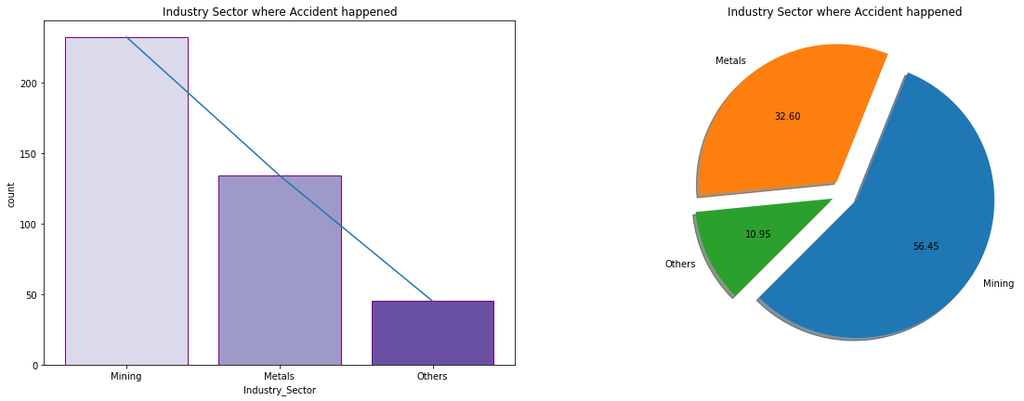

```python
plot('Industry_Sector', 'Industry Sector where Accident happened', 'Purples', 'Purple')
```

- It is clearly visibles that mining industries witness more accidents.

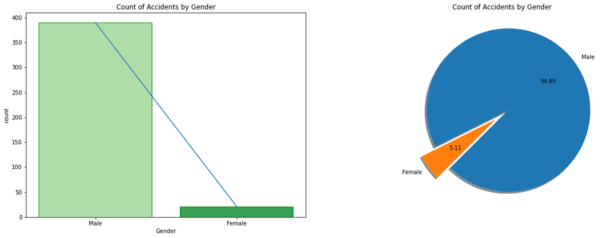

```python
#Gender
plot('Gender', 'Count of Accidents by Gender', 'Greens', 'Green')
```

As a characteristic of the industry, the proportion of male employees in accidents is more than female employees.

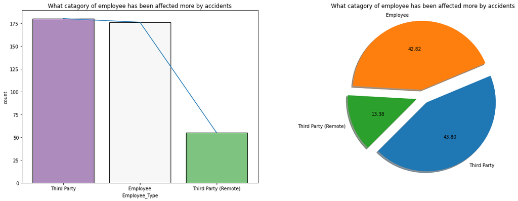

```python
#Employee type
plot('Employee_Type', 'What catagory of employee has been affected more by accidents', 'PRGn', 'black')
```

- Total number of Direct Employees and Third party employees are almost same, However, Third party remote employees are less in number.

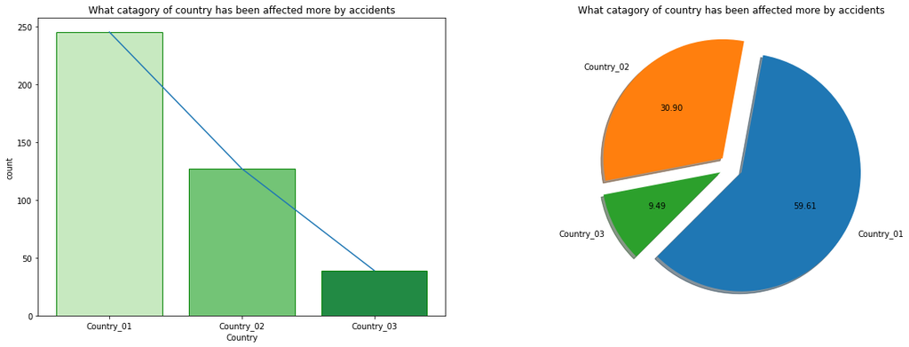

```python
#Country
plot('Country', 'What catagory of country has been affected more by accidents', 'Greens', 'Green')
```

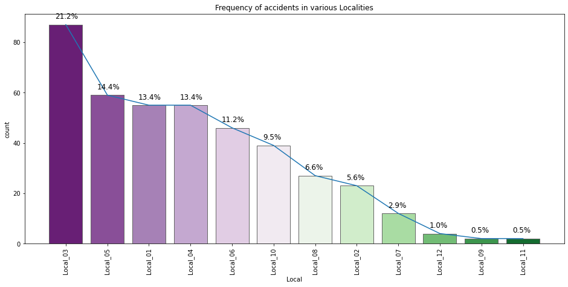

```python
# Locals Count
plt.figure(figsize = (16,7))
ax = sns.countplot(x = df['Local'], order=df['Local'].value_counts().index, palette = 'PRGn', edgecolor='.4', saturation=1);
sns.lineplot(df['Local'].value_counts().index, df['Local'].value_counts().values)

plt.title('Frequency of accidents in various Localities');
plt.xticks(rotation = 'vertical');

total = sum(df['Local'].value_counts())
for p in ax.patches:
    ax.annotate('{:.1f}%'.format(100*p.get_height()/total),
                (p.get_x(), p.get_height()),
                 size=12,
                 xytext = (10, 10),
                 textcoords = 'offset points')
```

Local_03 has recorded maximum number of accidents which is approx 21% of all the plants in the country.

This is followed by Local-05, Local-01 and so on.

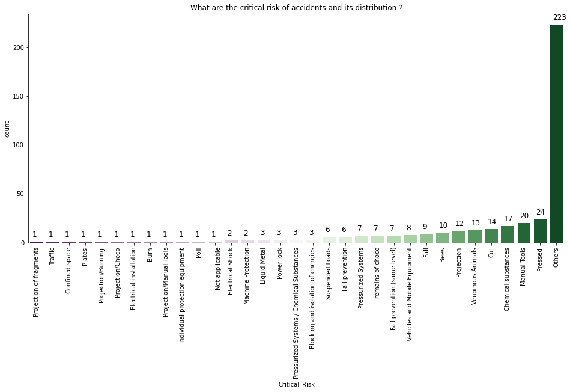

```python
# Critical Risk Count
plt.figure(figsize = (16,7))
ax = sns.countplot(x = df['Critical_Risk'], order=df['Critical_Risk'].value_counts().sort_values(ascending = True).index, palette = 'PRGn');
plt.title('What are the critical risk of accidents and its distribution ?');
plt.xticks(rotation = 'vertical');

total = sum(df['Critical_Risk'].value_counts())
for p in ax.patches:
    ax.annotate('{}'.format(p.get_height()),
                (p.get_x(), p.get_height()),
                 size=12,
                 xytext = (4, 8),
                 textcoords = 'offset points')
```

- Most of the Critical Risks are classified as 'Others' that is almost 50% of the dataset, hence there are too many risks need to be classified precisely. This is followed by Pressed, Manual tools, Chemical substances, Cut etc..

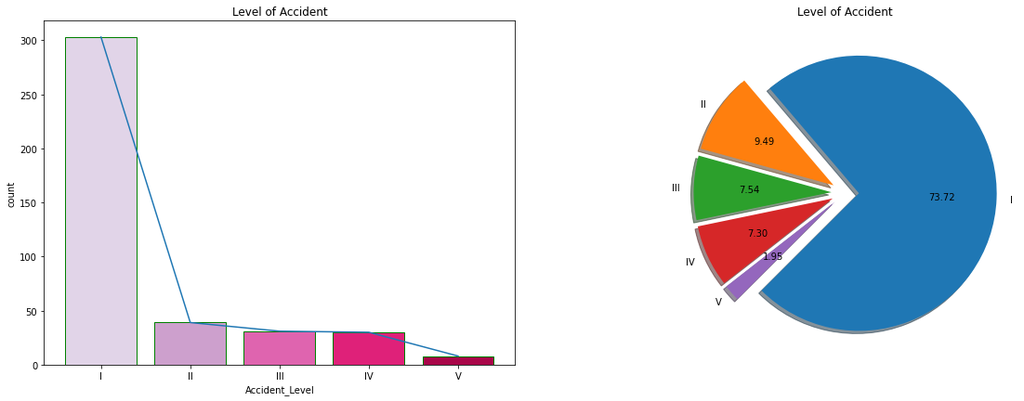

```python
plot('Accident_Level', 'Level of Accident', 'PuRd', 'Green')
```

- Level I signifies not severe and V signifies very severe.
- Accidents with the level I are most common. These are due to small misses, like people forgot their PPE, or they dropped a tool, etc.

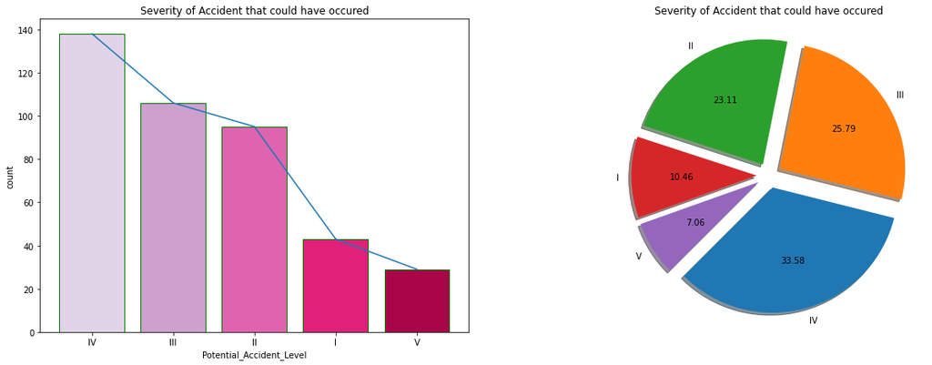

```python
plot('Potential_Accident_Level', 'Severity of Accident that could have occured', 'PuRd', 'green')
```

- Potential accident level indicates how severe the accident would been due to other factors involved in the accidents.
- Potential accident level IV has the highest count and signifies the moderate severity of accidents.
- We have to check the correlation of this Potential Accident level and Accident level along with the industry sector.

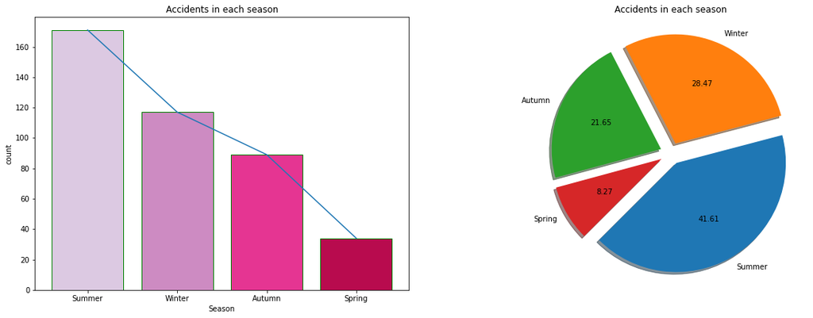

```python
plot('Season', 'Accidents in each season', 'PuRd', 'green')
```

- We can see that the number of accidents in summer season are highest.
- The number of accidents in Spring are least.

### Bivariate Analysis

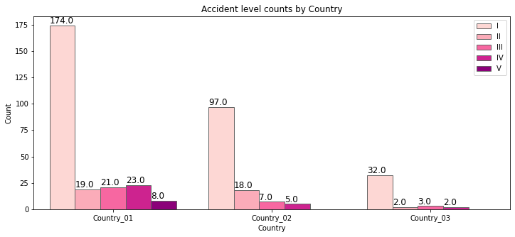

```python
#On target column
##Accident level counts by Country
plt.figure(figsize=(12,5))
ax = sns.countplot(df['Country'], hue=df['Accident_Level'], hue_order=df['Accident_Level'].value_counts().sort_index().index, palette='RdPu', edgecolor='.4', saturation=1)

total = sum(df['Country'].value_counts())
for p in ax.patches:
    ax.annotate('{}'.format(p.get_height()),
                (p.get_x(), p.get_height()),
                 size=12,
                 xytext = (0, 3),
                 textcoords = 'offset points')

plt.title('Accident level counts by Country');
plt.ylabel('Count');
plt.legend(loc='upper right')
```

- Country_01 has more number of severe accidents especially Level IV
- Country_02 has moderate accidents across all the levels.
- Country_03 has least number of accidents and no occurence of level 5 incidents ie severe accidents are reported.

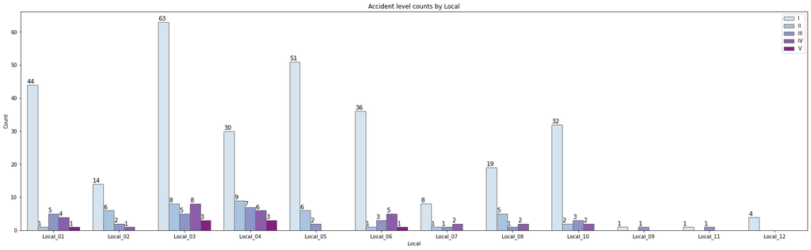

```python
#Accident level counts by
plt.figure(figsize=(28,8))
ax = sns.countplot(df['Local'], hue=df['Accident_Level'], hue_order=df['Potential_Accident_Level'].value_counts().sort_index().index, palette='BuPu', edgecolor='.4', saturation=1)

total = sum(df['Local'].value_counts())
for p in ax.patches:
    ax.annotate('{:.0f}'.format(p.get_height()),
                (p.get_x(), p.get_height()),
                 size=12,
                 xytext = (0, 3),
                 textcoords = 'offset points')

plt.title('Accident level counts by Local');
plt.ylabel('Count');
plt.legend(loc='upper right')
```

- Local_03 has maximum number of accidents as well as severe accidents.
- Local_09 ,Local_11 and Local_12 dont have any severe accidents and the number of accidents are also less than the others.

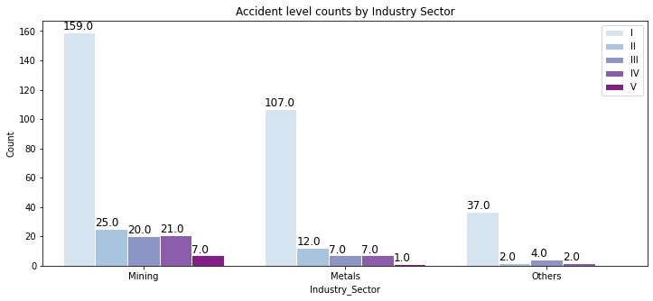

```python
#Accident level counts by Industry Sector
plt.figure(figsize=(12,5))
ax = sns.countplot(df['Industry_Sector'], hue=df['Accident_Level'], hue_order=df['Accident_Level'].value_counts().sort_index().index, palette='BuPu', edgecolor='1.0', saturation=1)

total = sum(df['Industry_Sector'].value_counts())
for p in ax.patches:
    ax.annotate('{}'.format(p.get_height()),
                (p.get_x(), p.get_height()),
                 size=12,
                 xytext = (0, 3),
                 textcoords = 'offset points')

plt.title('Accident level counts by Industry Sector');
plt.ylabel('Count');
plt.legend(loc='upper right')
```

- Mining Industry has highest number of accidents and also the severity of accidents is high.
- This is followed by Metal industry and other.

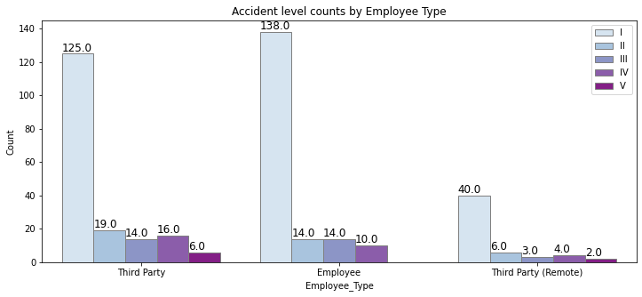

```python
#Accident level counts by Employee Type
plt.figure(figsize=(12,5))
ax = sns.countplot(df['Employee_Type'], hue=df['Accident_Level'], hue_order=df['Accident_Level'].value_counts().sort_index().index,
                   palette='BuPu', edgecolor='.5', saturation=1);

total = sum(df['Employee_Type'].value_counts())
for p in ax.patches:
    ax.annotate('{}'.format(p.get_height()),
                (p.get_x(), p.get_height()),
                 size=12,
                 xytext = (0, 3),
                 textcoords = 'offset points')

plt.title('Accident level counts by Employee Type');
plt.ylabel('Count');
plt.legend(loc='upper right')
```

- We see that employees have been most effected by level 1 accidents.
- Third party employees are more effected by severe accidents.

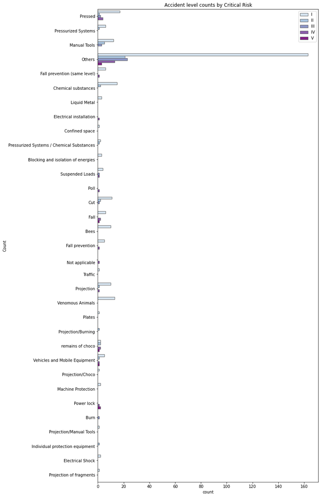

```python
#Accident level counts by Critical Risk
plt.figure(figsize=(10,22))
ax = sns.countplot(y =df['Critical_Risk'], hue=df['Accident_Level'], hue_order=df['Accident_Level'].value_counts().sort_index().index,
                   palette='BuPu', edgecolor='.4', saturation=1)


plt.title('Accident level counts by Critical Risk');
plt.ylabel('Count');
plt.legend(loc='upper right')
```

- We are not able to draw any conclusions from this visual we will keep exploring the variables for better understanding of our data.

```python
# Getting the value counts of each of the columns
accident = df['Accident_Level'].value_counts()
potential = df['Potential_Accident_Level'].value_counts()

# Merging both values of the dataframe
acc_pot = pd.concat([accident, potential], axis=1,sort=False).fillna(0).reset_index()

# Need to melt down columns so that they can be treated as hue in plotting
acc_pot = pd.melt(acc_pot, ['index'], var_name='Accident type', value_name='count')
acc_pot
```

|  | index | Accident type | count |
| --- | --- | --- | --- |
| 0 | I | Accident_Level | 303 |
| 1 | II | Accident_Level | 39 |
| 2 | III | Accident_Level | 31 |
| 3 | IV | Accident_Level | 30 |
| 4 | V | Accident_Level | 8 |
| 5 | I | Potential_Accident_Level | 43 |
| 6 | II | Potential_Accident_Level | 95 |
| 7 | III | Potential_Accident_Level | 106 |
| 8 | IV | Potential_Accident_Level | 138 |
| 9 | V | Potential_Accident_Level | 29 |

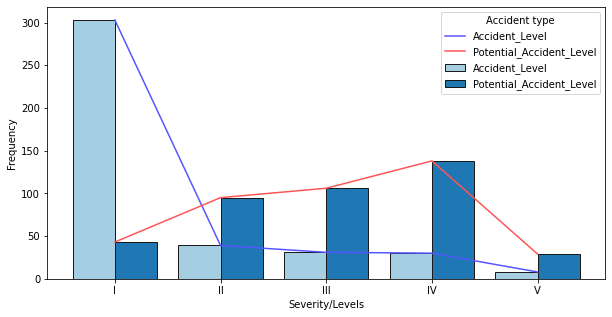

```python
#plotting
plt.figure(figsize=(10,5))
sns.barplot(acc_pot['index'], acc_pot['count'], hue=acc_pot['Accident type'], palette='Paired', edgecolor='.1', saturation=1)
sns.lineplot(acc_pot['index'], acc_pot['count'], hue=acc_pot['Accident type'], palette='seismic')

plt.xlabel('Severity/Levels');
plt.ylabel('Frequency');
```

- Notice there is a significant difference between the severity of an incident, and the potential severity of the incident.
- If the number of accidents increases, the potential accident level decreases There are high number of the Level 1 accidents.

Bivariate Analysis between the independent variables

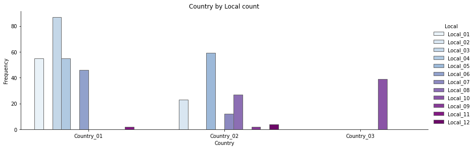

```python
#Accidents Count by Country and Local
# Country by Local count
plt.figure(figsize=(12,5))
sns.catplot(data=df, kind='count', x='Country', hue='Local', size=4, aspect=3, edgecolor='.4', saturation=1,palette='BuPu');
plt.title('Country by Local count');
plt.ylabel('Frequency');
```

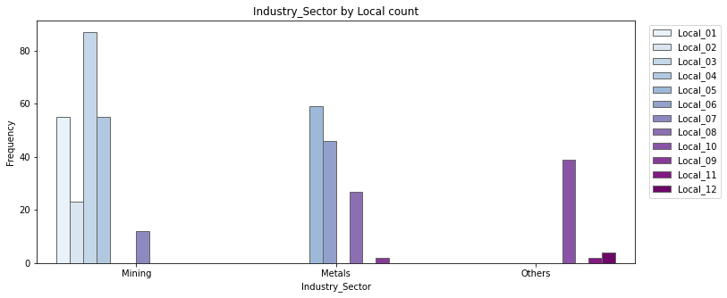

```python
#Accidents Count by Industry_Sector and Local
plt.figure(figsize=(12,5))
sns.countplot(df['Industry_Sector'], hue=df['Local'], edgecolor='.4', saturation=1, palette='BuPu');
plt.title('Industry_Sector by Local count');
plt.ylabel('Frequency')
plt.legend(loc='best', bbox_to_anchor=(1.15, 1))
```

- It can be observed that Industry Sector depends on the Local area too.
1. Local Area 1,2,3,4 and 7 belong to Mining Sector.
2. Local Area 5,6,8 and 9 belong to Metal Sector.
3. Local Area 10, 11 and 12 belong to Other Sectors.

```python
#Employeee type by Gender Count
#Since Gender is more biased towards male, we are taking ratio count with respect to other variables
# Filtering the dataframe by Gender and Employee type and taking the count.
df1 = df.groupby(['Gender','Employee_Type'])['Employee_Type'].count()

# 1.unstack() Function in dataframe unstacks the row to columns.
# 2.applying the row total and taking the ratio of male and female employees.
# 3.resetting the index

df1 = df1.unstack().apply(lambda x: round(x / x.sum()*100), axis=1).reset_index()
df1 = pd.melt(df1, ['Gender']) # melt() function unpivots a DataFrame from wide format to long format
df1
```

|  | Gender | Employee_Type | value |
| --- | --- | --- | --- |
| 0 | Female | Employee | 38.0 |
| 1 | Male | Employee | 43.0 |
| 2 | Female | Third Party | 38.0 |
| 3 | Male | Third Party | 44.0 |
| 4 | Female | Third Party (Remote) | 24.0 |
| 5 | Male | Third Party (Remote) | 13.0 |

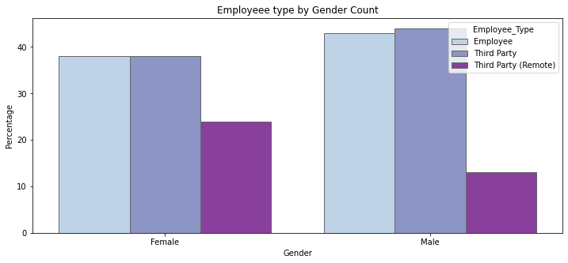

```python
plt.figure(figsize=(12,5))
sns.barplot(df1['Gender'], df1['value'], hue=df1['Employee_Type'],  edgecolor='.4', saturation=1, palette='BuPu');
plt.title('Employeee type by Gender Count');
plt.ylabel('Percentage');
```

```python
#Industry_Sector by Gender Count
# Filtering the dataframe by Gender and Employee type and taking the count.
df1 = pd.melt(df.groupby(['Gender','Industry_Sector'])['Industry_Sector'].count().unstack().apply(lambda x: round(x / x.sum()*100), axis=1).reset_index(),['Gender'])
df1
```

|  | Gender | Industry_Sector | value |
| --- | --- | --- | --- |
| 0 | Female | Metals | 62.0 |
| 1 | Male | Metals | 31.0 |
| 2 | Female | Mining | 19.0 |
| 3 | Male | Mining | 58.0 |
| 4 | Female | Others | 19.0 |
| 5 | Male | Others | 11.0 |

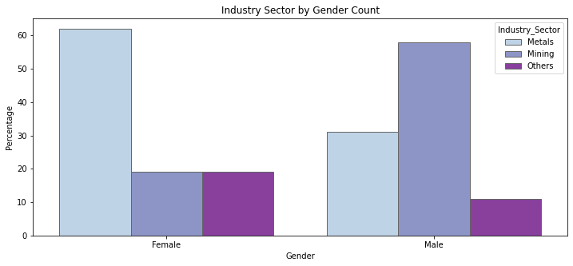

```python
plt.figure(figsize=(12,5))
sns.barplot(df1['Gender'], df1['value'], hue=df1['Industry_Sector'], palette='BuPu', edgecolor='.4', saturation=1);
plt.title('Industry Sector by Gender Count');
plt.ylabel('Percentage');
```

- There is a major diferrence in mining and metals industries within males and females
- We can observe the distinct safety levels by the industry sectors towards male and female

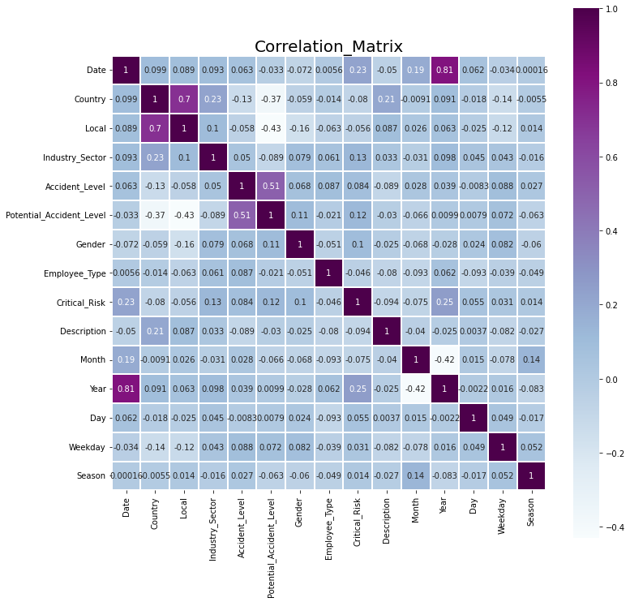

```python
# Correlation plot
# Correlation
le = LabelEncoder()
df_enc = df.apply(le.fit_transform)

plt.figure(figsize=(12,12))
plt.title('Correlation_Matrix', fontsize=20)
sns.heatmap(df_enc.corr(), square=True, cmap='BuPu', annot=True, linewidth=0.2);
```

- we can see that Potential Accident Level and Accident level are moderatly correlated.
- Also, there is high correlation in country and Local as observeed earlier

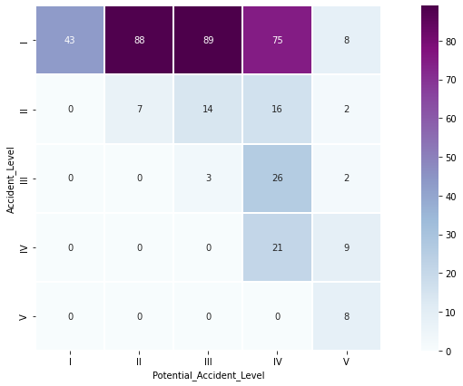

```python
# Count of Accidents grouped by Accident Level and Potential accident level
plt.figure(figsize = (16,7))
sns.heatmap(pd.crosstab(df.Accident_Level, df.Potential_Accident_Level), square=True, cmap='BuPu', annot=True, linewidth=0.1);
```

```python
# Count of Critical Risks grouped by Industry sectors
df.pivot_table(index='Critical_Risk', columns='Industry_Sector', aggfunc='count').fillna(0)['Accident_Level'].T
```

| Critical_Risk Industry_Sector | \nNot applicable | Bees | Blocking and isolation of energies | Burn | Chemical substances | Confined space | Cut | Electrical Shock | Electrical installation | Fall | ... | Projection | Projection of fragments | Projection/Burning | Projection/Choco | Projection/Manual Tools | Suspended Loads | Traffic | Vehicles and Mobile Equipment | Venomous Animals | remains of choco |
| --- | --- | --- | --- | --- | --- | --- | --- | --- | --- | --- | --- | --- | --- | --- | --- | --- | --- | --- | --- | --- | --- |
| Metals | 1.0 | 0.0 | 3.0 | 1.0 | 15.0 | 1.0 | 10.0 | 0.0 | 0.0 | 2.0 | ... | 4.0 | 0.0 | 1.0 | 0.0 | 0.0 | 5.0 | 0.0 | 0.0 | 2.0 | 0.0 |
| Mining | 0.0 | 0.0 | 0.0 | 0.0 | 2.0 | 0.0 | 4.0 | 2.0 | 1.0 | 5.0 | ... | 8.0 | 1.0 | 0.0 | 0.0 | 1.0 | 1.0 | 0.0 | 8.0 | 1.0 | 7.0 |
| Others | 0.0 | 10.0 | 0.0 | 0.0 | 0.0 | 0.0 | 0.0 | 0.0 | 0.0 | 2.0 | ... | 0.0 | 0.0 | 0.0 | 1.0 | 0.0 | 0.0 | 1.0 | 0.0 | 10.0 | 0.0 |

3 rows × 33 columns

### Time Series Analysis

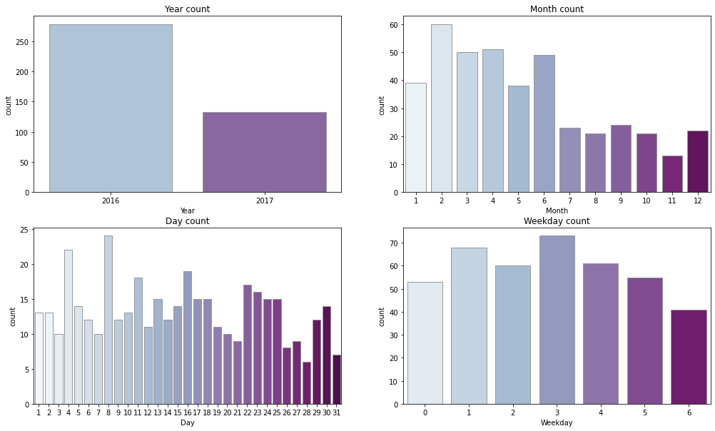

```python
k=1
plt.figure(figsize=(17,10))

# using for loop to iterate over defined columns in the dataframe and create the plot

for col in df[['Year', 'Month', 'Day', 'Weekday']]:
    plt.subplot(2,2,k)
    sns.countplot(df[col],edgecolor = '.6', alpha = 1.0,palette='BuPu')
    # sns.lineplot(df[col].value_counts().index, df[col].value_counts().values, palette='seismic')
    plt.title(col+' count')
    k=k+1
```

- It can be observed that more number of accidents occured in 2016 compared to 2017 as expected since we have complete data for the year 2016 and only 7 months data for 2017.
- Number of accidents are high dring mid week and low around the weekend.

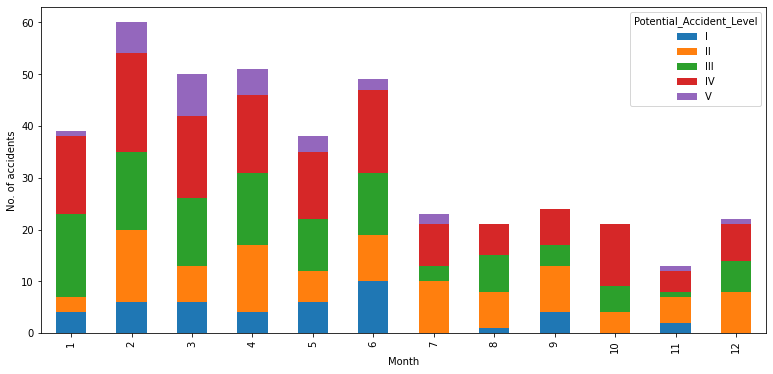

```python
#Potential Accident level counts by Month
ct = pd.crosstab(columns=df["Potential_Accident_Level"],index=df["Month"])
ax = ct.plot(kind="bar",stacked=True,figsize=(13,6))
ax.set_ylabel('No. of accidents')
ax.set_xlabel('Month')
```

```python
#Step 4: Data preparation for Model
#cheking the columns
df.columns
```

```
Index(['Date', 'Country', 'Local', 'Industry_Sector', 'Accident_Level',
       'Potential_Accident_Level', 'Gender', 'Employee_Type', 'Critical_Risk',
       'Description', 'Month', 'Year', 'Day', 'Weekday', 'Season'],
      dtype='object')
```

```python
df_latest = df.copy()
# Removing date column from further modeling & analysis
df_latest.drop(columns=['Date','Month', 'Season', 'Year', 'Day', 'Weekday'], inplace= True)
```

```python
df_latest.head()
```

|  | Country | Local | Industry_Sector | Accident_Level | Potential_Accident_Level | Gender | Employee_Type | Critical_Risk | Description |
| --- | --- | --- | --- | --- | --- | --- | --- | --- | --- |
| 0 | Country_01 | Local_01 | Mining | I | IV | Male | Third Party | Pressed | While removing the drill rod of the Jumbo 08 f... |
| 1 | Country_02 | Local_02 | Mining | I | IV | Male | Employee | Pressurized Systems | During the activation of a sodium sulphide pum... |
| 2 | Country_01 | Local_03 | Mining | I | III | Male | Third Party (Remote) | Manual Tools | In the sub-station MILPO located at level +170... |
| 3 | Country_01 | Local_04 | Mining | I | I | Male | Third Party | Others | Being 9:45 am. approximately in the Nv. 1880 C... |
| 4 | Country_01 | Local_04 | Mining | IV | IV | Male | Third Party | Others | Approximately at 11:45 a.m. in circumstances t... |

## Milestone 2

```python
#Label Accident Level to numeric category
Accident_Level = {
    'I'   :   1,
    'II'  :   2,
    'III' :   3,
    'IV'  :   4,
    'V'   :   5,
    'VI'   :   6
}
df_latest['Accident_Level'] = df_latest['Accident_Level'].map(Accident_Level)
```

```python
df_latest.columns
```

```
Index(['Country', 'Local', 'Industry_Sector', 'Accident_Level',
       'Potential_Accident_Level', 'Gender', 'Employee_Type', 'Critical_Risk',
       'Description'],
      dtype='object')
```

```python
#Apply get_dummies to columns to get data in the form of 0's and 1's
df_latest = pd.get_dummies(df_latest, columns=['Country','Critical_Risk','Local','Industry_Sector','Gender','Employee_Type'],prefix='Dummy',drop_first=True)
```

```python
df_latest['Description'][0]
```

```
'While removing the drill rod of the Jumbo 08 for maintenance, the supervisor proceeds to loosen the support of the intermediate centralizer to facilitate the removal, seeing this the mechanic supports one end on the drill of the equipment to pull with both hands the bar and accelerate the removal f…
```

Cleaning up the data,removing stopwords,remove punctuation, converting them into tokens.

```python
import string
import re
import os
import nltk

from nltk.tokenize import TweetTokenizer
from nltk.corpus import stopwords, twitter_samples
```

```python
from nltk.corpus import stopwords
nltk.download('stopwords')
```

```
True
```

```python
#treatmen of 'Description" column i.e Preprocess unstructured data to make it consumable for model training.
#A. Remove unwanted chars other than alphanumeric
#B. Lowercase all textual data
#C. Remove all extra white spaces
#D. Remove all Stopwords
```

```python
#Remove unwanted chars other than alphanumeric
pattern = "[^a-zA-Z.,!?/:;\"\'\s]"
df_latest.Description = df_latest.Description.apply(lambda s : re.sub(pattern,"",s))
```

```python
#Lowercase all textual data
df_latest.Description = df_latest.Description.apply(lambda s: s.lower())
```

```python
#Remove all extra white spaces
df_latest.Description = df_latest.Description.apply(lambda s: s.strip())
```

```python
df_latest.head()
```

|  | Accident_Level | Potential_Accident_Level | Description | Dummy_Country_02 | Dummy_Country_03 | Dummy_Bees | Dummy_Blocking and isolation of energies | Dummy_Burn | Dummy_Chemical substances | Dummy_Confined space | ... | Dummy_Local_08 | Dummy_Local_09 | Dummy_Local_10 | Dummy_Local_11 | Dummy_Local_12 | Dummy_Mining | Dummy_Others | Dummy_Male | Dummy_Third Party | Dummy_Third Party (Remote) |
| --- | --- | --- | --- | --- | --- | --- | --- | --- | --- | --- | --- | --- | --- | --- | --- | --- | --- | --- | --- | --- | --- |
| 0 | 1 | IV | while removing the drill rod of the jumbo for... | 0 | 0 | 0 | 0 | 0 | 0 | 0 | ... | 0 | 0 | 0 | 0 | 0 | 1 | 0 | 1 | 1 | 0 |
| 1 | 1 | IV | during the activation of a sodium sulphide pum... | 1 | 0 | 0 | 0 | 0 | 0 | 0 | ... | 0 | 0 | 0 | 0 | 0 | 1 | 0 | 1 | 0 | 0 |
| 2 | 1 | III | in the substation milpo located at level when... | 0 | 0 | 0 | 0 | 0 | 0 | 0 | ... | 0 | 0 | 0 | 0 | 0 | 1 | 0 | 1 | 0 | 1 |
| 3 | 1 | I | being : am. approximately in the nv. cx ob, t... | 0 | 0 | 0 | 0 | 0 | 0 | 0 | ... | 0 | 0 | 0 | 0 | 0 | 1 | 0 | 1 | 1 | 0 |
| 4 | 4 | IV | approximately at : a.m. in circumstances that ... | 0 | 0 | 0 | 0 | 0 | 0 | 0 | ... | 0 | 0 | 0 | 0 | 0 | 1 | 0 | 1 | 1 | 0 |

5 rows × 53 columns

```python
df_latest.shape
```

```
(411, 53)
```